# TalkingData AdTracking Fraud Detection

Matheus C. Andrade

6/15/2021

# 0. Collecting the data

```r
## Setting the working directory
#setwd("~/Development/DataScienceAcademy/FCD/BigDataRAzure/ProjetoFinal/TalkingData-AdTracking-Fraud-Detection/EDA")
getwd()
```

```
## [1] "/home/matheus/Development/DataScienceAcademy/FCD/BigDataRAzure/ProjetoFinal/TalkingData-AdTracking-Fraud-Detection/EDA"
```

```r
## Libraries
library(data.table)
#library(Amelia)
library(dplyr)
```

```r
library(ggplot2)
library(treemap)
library(gridExtra)
library(corrplot)
## Loading dataset
df_original <- fread("../Datasets/train_sample.csv", header=T)
# df <- fread(file.choose(), header=T)
df <- df_original
```

# 1. Exploratory Data Analysis

## 1st EDA Stage: Knowing the data as they are

```r
str(df) #glipmse(df)
```

```
## Classes 'data.table' and 'data.frame':   100000 obs. of  8 variables:
##  $ ip             : int  87540 105560 101424 94584 68413 93663 17059 121505 192967 143636 ...
##  $ app            : int  12 25 12 13 12 3 1 9 2 3 ...
##  $ device         : int  1 1 1 1 1 1 1 1 2 1 ...
##  $ os             : int  13 17 19 13 1 17 17 25 22 19 ...
##  $ channel        : int  497 259 212 477 178 115 135 442 364 135 ...
##  $ click_time     : POSIXct, format: "2017-11-07 09:30:38" "2017-11-07 13:40:27" ...
##  $ attributed_time: POSIXct, format: NA NA ...
##  $ is_attributed  : int  0 0 0 0 0 0 0 0 0 0 ...
##  - attr(*, ".internal.selfref")=<externalptr>
```

```r
dim(df)
```

```
## [1] 100000      8
```

```r
summary(df)
```

```
##        ip              app             device              os
##  Min.   :     9   Min.   :  1.00   Min.   :   0.00   Min.   :  0.00
##  1st Qu.: 40552   1st Qu.:  3.00   1st Qu.:   1.00   1st Qu.: 13.00
##  Median : 79827   Median : 12.00   Median :   1.00   Median : 18.00
##  Mean   : 91256   Mean   : 12.05   Mean   :  21.77   Mean   : 22.82
##  3rd Qu.:118252   3rd Qu.: 15.00   3rd Qu.:   1.00   3rd Qu.: 19.00
##  Max.   :364757   Max.   :551.00   Max.   :3867.00   Max.   :866.00
##
##     channel        click_time                  attributed_time
##  Min.   :  3.0   Min.   :2017-11-06 16:00:00   Min.   :2017-11-06 17:19:04
##  1st Qu.:145.0   1st Qu.:2017-11-07 11:34:09   1st Qu.:2017-11-07 11:50:27
##  Median :258.0   Median :2017-11-08 07:07:50   Median :2017-11-08 06:43:39
##  Mean   :268.8   Mean   :2017-11-08 06:29:52   Mean   :2017-11-08 07:04:12
##  3rd Qu.:379.0   3rd Qu.:2017-11-09 02:06:01   3rd Qu.:2017-11-09 01:42:52
##  Max.   :498.0   Max.   :2017-11-09 15:59:51   Max.   :2017-11-09 15:28:15
##                                                NA's   :99773
##  is_attributed
##  Min.   :0.00000
##  1st Qu.:0.00000
##  Median :0.00000
##  Mean   :0.00227
##  3rd Qu.:0.00000
##  Max.   :1.00000
##
```

```r
## Duplicated rows analysis
any(duplicated(df))
```

```
## [1] TRUE
```

```r
# what are this rows?
df[duplicated(df), ] #df %>% !distinct() # There is one
```

| ip | app | device | os | channel | click_time | attributed_time | is_attributed |
| --- | --- | --- | --- | --- | --- | --- | --- |
| 871 | 12 | 1 | 13 | 178 | 2017-11-08 10:00:05 |  | 0 |

```r
# removing duplicated rows
df <- df[!duplicated(df), ]
any(duplicated(df))
```

```
## [1] FALSE
```

```r
## quantity of null values in each columns
any(is.na(df))
```

```
## [1] TRUE
```

```r
# missmap(df, main = "Missing Values Map", col = c("red", "black"), legend = FALSE)
sapply(df, function(x) sum(is.na(x)))
```

```
##              ip             app          device              os         channel
##               0               0               0               0               0
##      click_time attributed_time   is_attributed
##               0           99772               0
```

```r
# just 'attributed_time' has null values: 99773
sum(is.na(df[,"attributed_time"]))/length(df$attributed_time)*100
```

```
## [1] 99.773
```

```r
# as for the users who didn't download the app, the time has not been recorded
# and the column wasn't filled with any value

## quantity of unique values in each columns
sapply(df, function(x) length(unique(x)))
```

```
##              ip             app          device              os         channel
##           34857             161             100             130             161
##      click_time attributed_time   is_attributed
##           80350             228               2
```

```r
# the label column is a factor with two levels
df$is_attributed <- as.factor(df$is_attributed)

# "ip", "app", "device", "os", "channel" are also factor type
df[,1:5] <- lapply(df[,1:5], factor)#######
#str(df)

## High class imbalance problem
summary(df$is_attributed) #table(df$is_attributed)
```

```
##     0     1
## 99772   227
```

```r
prop.table(table(df$is_attributed))*100
```

```
##
##          0          1
## 99.7729977  0.2270023
```

```r
# it means that the models will be overfitted about no-downloads

## when "attributed_time" is NULL "is_attributed" is 0.
# there isn't attributed_time when there wasn't made download

## Generating weekday and hour from click_time intending to explore days and hours
# 'weekdays' to names, 'wday' to numbers (it starts with 0 = Sunday)
df$weekday <- weekdays(df$click_time)
df$hour <- hour(df$click_time)
#glimpse(df)
# quantity of unique values in the new columns
sapply(df[, 9:10], function(x) length(unique(x)))
```

```
## weekday    hour
##       4      24
```

```r
## changing the columns order
# names(df)
df <- df[, c(6,9,10,1,2,3,4,5,7,8)]

# changing for factor the new columns
df$weekday <- as.factor(df$weekday)
df$hour <- as.factor(df$hour)

# after data munging, just confirming whether the data integrity is as before
sapply(df, function(x) sum(is.na(x)))
```

```
##      click_time         weekday            hour              ip             app
##               0               0               0               0               0
##          device              os         channel attributed_time   is_attributed
##               0               0               0           99772               0
```

```r
sapply(df, function(x) length(unique(x)))
```

```
##      click_time         weekday            hour              ip             app
##           80350               4              24           34857             161
##          device              os         channel attributed_time   is_attributed
##             100             130             161             228               2
```

```r
## Creating subsets from is_attributed classes
df_IsAttributed0 <- df %>%
  filter(is_attributed == '0')

df_IsAttributed1 <- df %>%
  filter(is_attributed == '1') %>%
  mutate(wday_IsAttributed1 = weekdays(attributed_time),
         hour_IsAttributed1 = hour(attributed_time))

# as attributed_time represents the event time we want predict, it's deleted
df$attributed_time = NULL

summary(df)
```

```
##    click_time                       weekday           hour
##  Min.   :2017-11-06 16:00:00   Monday   : 5011   4      : 6039
##  1st Qu.:2017-11-07 11:34:09   Thursday :28561   0      : 5654
##  Median :2017-11-08 07:07:49   Tuesday  :32393   13     : 5619
##  Mean   :2017-11-08 06:29:52   Wednesday:34034   14     : 5561
##  3rd Qu.:2017-11-09 02:06:01                     10     : 5510
##  Max.   :2017-11-09 15:59:51                     5      : 5400
##                                                  (Other):66216
##        ip             app            device            os
##  5348   :  669   3      :18279   1      :94337   19     :23870
##  5314   :  616   12     :13197   2      : 4345   13     :21222
##  73487  :  439   2      :11737   0      :  541   17     : 5232
##  73516  :  399   9      : 8992   3032   :  371   18     : 4830
##  53454  :  280   15     : 8595   3543   :  151   22     : 4039
##  114276 :  219   18     : 8315   3866   :   93   10     : 2816
##  (Other):97377   (Other):30884   (Other):  161   (Other):37990
##     channel      is_attributed
##  280    : 8114   0:99772
##  245    : 4802   1:  227
##  107    : 4543
##  477    : 3960
##  134    : 3224
##  259    : 3130
##  (Other):72226
```

## 2nd EDA Stage: Exploratory Data Analysis

### 2.1 Bar plots

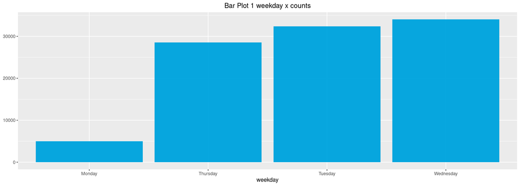

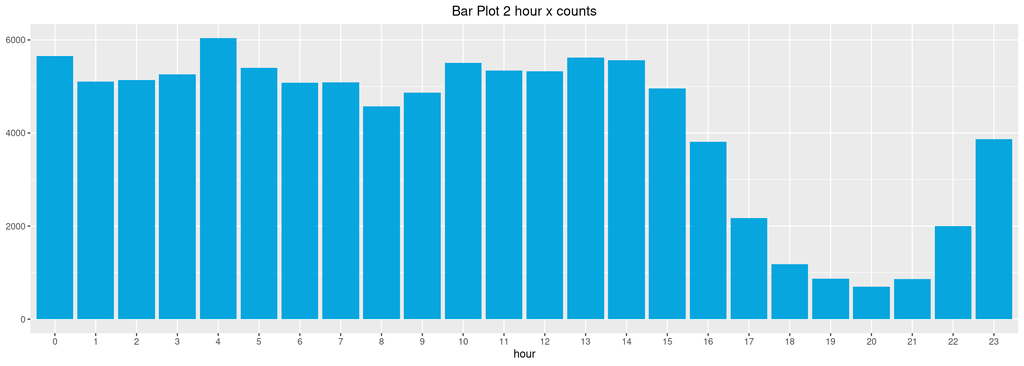

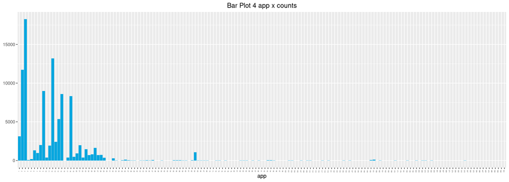

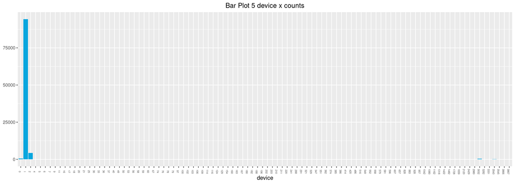

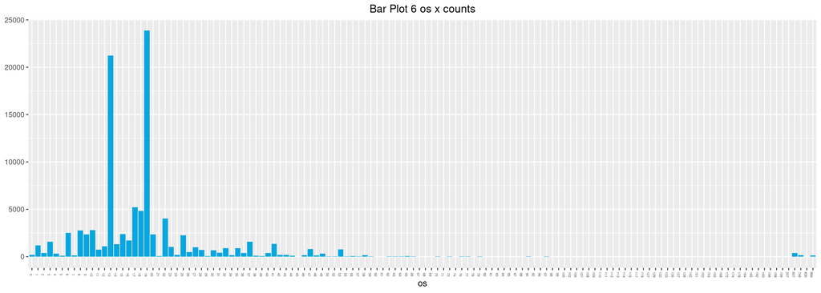

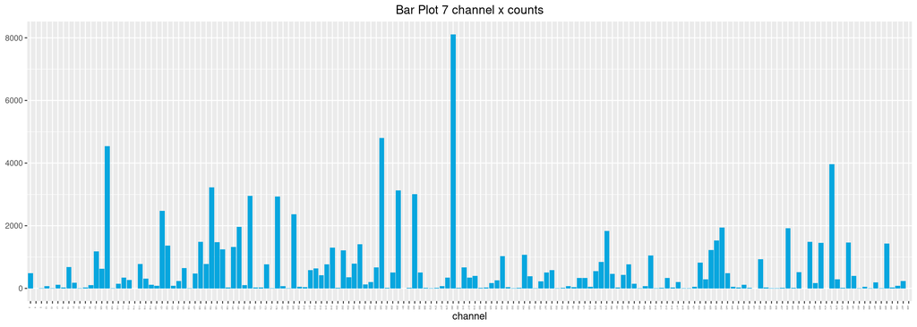

```r
# For categorical variables (or grouping variables).
# the count of categories is visualized using a bar plot, pie chart or dot charts to show the proportion of each category.

# creating a list with the same dataset rows length
df_subsets <- list(1:nrow(df))
#df_subsets[[1]][1]

# creting a aux dataset with only columns in df_subsets
df_aux <- df[, 2:8] # without click_time, which is represented by hour and weekday columns


### 2.1.1 Creating dataset for each variable counting its frequency
for(i in 1:7){
  #print(names(df_dataSets[i]) )
  df_subsets[[i]] <- df_aux %>%
    group_by_at(i) %>%
    summarise(counts = n())
}
#View(df_subsets)

### 2.1.2 Creating bar plots for each variable counting its frequency from its datasets
# automatizing visualization for bar plots
for (i in 1:length(df_subsets)){

  if(i==3)
    next # as the IP bar plot is heavy for load, this bar is omitted

  x_column <- unlist(df_subsets[[i]][,1])
  title_x <- names(df_subsets[[i]][,1])
  title_y <- names(df_subsets[[i]][,2])


  barplot <- ggplot(df_subsets[[i]],aes(x = x_column , y = counts)) +
    geom_bar(fill = "#00A4DEF7", stat = "identity") +
    #geom_text(aes(label = counts), vjust = -0.3, size = 3) +
    ggtitle(paste("Bar Plot", i, title_x,"x", title_y)) +
    theme(plot.title = element_text(hjust = 0.5),
          #axis.title.x=element_blank(),
          axis.title.y=element_blank()) +
    xlab(title_x)

  print(barplot +
          if (i == 3)
            theme(axis.text.x = element_text(angle=-90, size=0))
          else if (i == 4)
            theme(axis.text.x = element_text(angle=-90, size=3))
          else if (i == 5)
            theme(axis.text.x = element_text(angle=-90, size=5))
          else if (i == 6)
            theme(axis.text.x = element_text(angle=-90, size=4))
          else if (i == 7)
            theme(axis.text.x = element_text(angle=-90, size=2.5)))
}
```

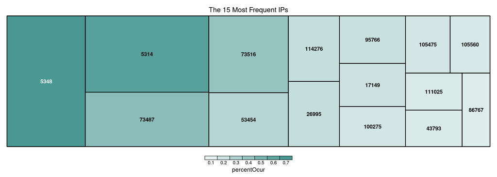

```r
ip = as.data.frame(df_subsets[[3]])
ip <- ip %>% arrange(desc(counts)) %>%
  mutate(percentOcur = round(prop.table(counts),4)*100)
treemap(ip[1:15,],
  index="ip", vSize="counts", vColor="percentOcur",
  palette=c("White","White", "#499894"), # "YlOrRd"
  type="value", title.legend="percentOcur", title="The 15 Most Frequent IPs")
```

Day: wednesday > tuesday > thursday > monday (a lot less)

Hour: between 17 and 22 hour is made less download; great peak: 0h to 15h; peak 1 is 0h to 7h; peak 2 is 9h to 15h; curiously 8 has the minor value compared with its proximities; @ that’s interesting to relate day and hour together;

App: in general, the firsts are more downloaded, but there is some whose highlight a tiny and one who highlight a lot more;

Device: there is one who highlights in a huge way;

OS: there are 2 who highlight a lot;

Channel: there is one that stands out a lot and others who highlights less;

### 2.2 Exploring hour and weekday

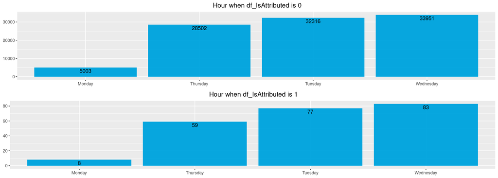

```r
### 2.2.1 is_attributed frequency: comparison between download and no-download
# is_attributed0 weekday
df_IsAttributed0Day <- df_IsAttributed0 %>%
  group_by(weekday) %>%
  summarise(counts = n())

p1_IsA_Day <- ggplot(df_IsAttributed0Day, aes(x = weekday, y = counts)) +
  geom_bar(fill = "#00A4DEF7", stat = "identity") +
  geom_text(aes(label = counts), vjust = 1.3) +
  ggtitle(" Hour when df_IsAttributed is 0") +
  theme(plot.title = element_text(hjust = 0.5),
        axis.title.x=element_blank(),
        axis.title.y=element_blank())

# is_attributed1 weekday
df_IsAttributed1Day <- df_IsAttributed1 %>%
  group_by(weekday) %>%
  summarise(counts = n())

p2_IsA_Day <- ggplot(df_IsAttributed1Day, aes(x = weekday, y = counts)) +
  geom_bar(fill = "#00A4DEF7", stat = "identity") +
  geom_text(aes(label = counts), vjust = 1.3) +
  ggtitle(" Hour when df_IsAttributed is 1") +
  theme(plot.title = element_text(hjust = 0.5),
        axis.title.x=element_blank(),
        axis.title.y=element_blank())

grid.arrange(p1_IsA_Day, p2_IsA_Day, ncol = 1)
```

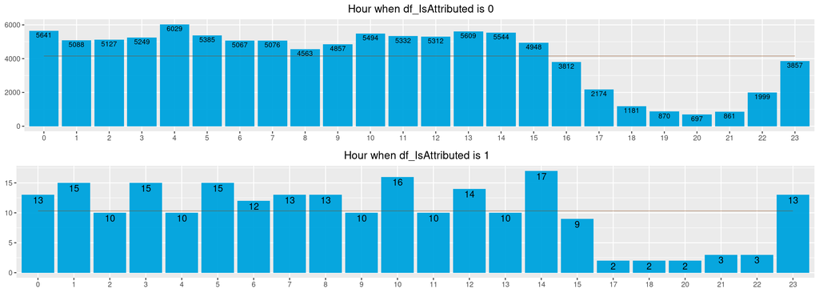

```r
# Apparently there isn't no significant difference

# is_attributed0 hour
df_IsAttributed0Hour <- df_IsAttributed0 %>%
  group_by(hour) %>%
  summarise(counts = n())

p1_IsA_Hour <- ggplot(df_IsAttributed0Hour, aes(x = hour, y = counts)) +
  geom_bar(fill = "#00A4DEF7", stat = "identity") +
  geom_text(aes(label = counts), vjust = 1.3, size = 3) +
  ggtitle(" Hour when df_IsAttributed is 0") +
  theme(plot.title = element_text(hjust = 0.5),
        # axis.text.x = element_text(size=5)
        axis.title.x=element_blank(),
        axis.title.y=element_blank()) +
  geom_line(aes(x = hour, y = mean(counts)), size = 0.2, color="#8B4513", group = 1)

# is_attributed1 hour
df_IsAttributed1Hour <- df_IsAttributed1 %>%
  group_by(hour) %>%
  summarise(counts = n())

p2_IsA_Hour <- ggplot(df_IsAttributed1Hour, aes(x = hour, y = counts)) +
  geom_bar(fill = "#00A4DEF7", stat = "identity") +
  geom_text(aes(label = counts), vjust = 1.3, size = 4) +
  ggtitle(" Hour when df_IsAttributed is 1") +
  theme(plot.title = element_text(hjust = 0.5),
        # axis.text.x = element_text(size=5)
        axis.title.x=element_blank(),
        axis.title.y=element_blank()) +
  geom_line(aes(x = hour, y = mean(counts)), size = 0.2, color="#8B4513", group = 1)

grid.arrange(p1_IsA_Hour, p2_IsA_Hour, ncol = 1)
```

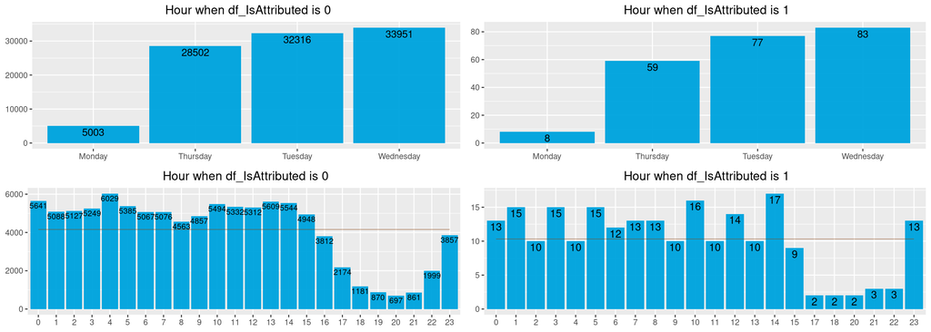

```r
grid.arrange(p1_IsA_Day, p2_IsA_Day, p1_IsA_Hour, p2_IsA_Hour, ncol = 2)
```

There is a significative difference between that hour download was made.

It’s interesting to use statistics to know more about this difference, but basically, the no-downloads happened more between 0 to 15h.

In this sample, there isn’t download at the 16h, but there is a lot no-download.

```r
### 2.2.2 investigating more the relations between day and time variables
# is_attributed0 hour x day
df_IsAttributed0HourDay <- df_IsAttributed0 %>%
  group_by(weekday,hour) %>%
  summarise(counts = n())
```

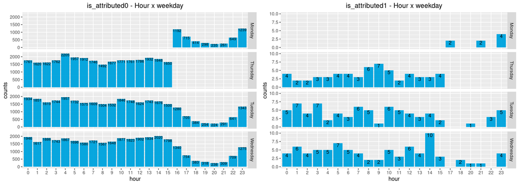

```r
a <- ggplot(df_IsAttributed0HourDay, aes(x = hour, y = counts)) +
  geom_bar(fill = "#00A4DEF7", stat = "identity") +
  facet_grid(weekday ~ .) +
  geom_text(aes(label = counts), vjust = 1, size = 2.5) +
  ggtitle("is_attributed0 - Hour x weekday") +
  theme(#axis.text.x = element_text(size=5),
        plot.title = element_text(hjust = 0.5))

# is_attributed1 hour x day
df_IsAttributed1HourDay <- df_IsAttributed1 %>%
  group_by(weekday,hour) %>%
  summarise(counts = n())
b <- ggplot(df_IsAttributed1HourDay, aes(x = hour, y = counts)) +
  geom_bar(fill = "#00A4DEF7", stat = "identity") +
  facet_grid(weekday ~ .) +
  geom_text(aes(label = counts), vjust = 1, size = 3.5) +
  ggtitle("is_attributed1 - Hour x weekday") +
  theme(#axis.text.x = element_text(size=5),
        plot.title = element_text(hjust = 0.5))

# there wasn't downloads at Thursday in 17 to 03h
grid.arrange(a, b, ncol = 2)
```

## 3rd EDA Stage: Correlation

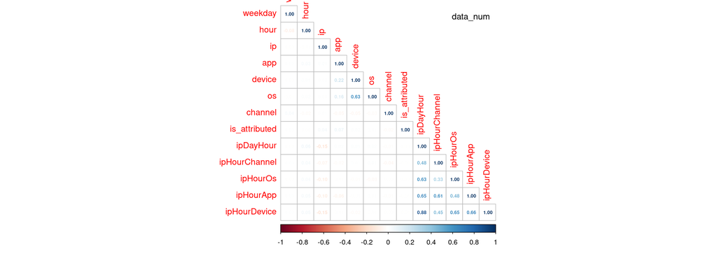

```r
# Generating new columns from 'IP' relating it with another columns
data <- df %>%
  add_count(ip, weekday, hour) %>% rename("ipDayHour"     = n) %>%
  add_count(ip, hour, channel) %>% rename("ipHourChannel" = n) %>%
  add_count(ip, hour, os)      %>% rename("ipHourOs"      = n) %>%
  add_count(ip, hour, app)     %>% rename("ipHourApp"     = n) %>%
  add_count(ip, hour, device)  %>% rename("ipHourDevice"  = n)%>%
  select(-click_time)
# 'click_time' isn't necessary as we already have created weekday and hour columns

## Creating a dataset for doesn't alter the original
data_num <- data
# to observe how much each variable correlates depending if it was made download or no
data_0 <- data %>%
  filter(is_attributed == '0') %>%
  select(-is_attributed)
data_1 <- data %>%
  filter(is_attributed == '1') %>%
  select(-is_attributed)

# converting to numeric to correlate variables
data_num[,1:ncol(data_num)] = lapply(data_num[,1:ncol(data_num)], as.numeric)
data_0[,1:ncol(data_0)] <- lapply(data_0[,1:ncol(data_0)], as.numeric)
data_1[,1:ncol(data_1)] <- lapply(data_1[,1:ncol(data_1)], as.numeric)

## correlations
corrplot(cor(data_num, method="pearson"), method = 'number',
         number.cex= 7/ncol(data_num), type="lower")
mtext("data_num", at=12, line=2, cex=1)
```

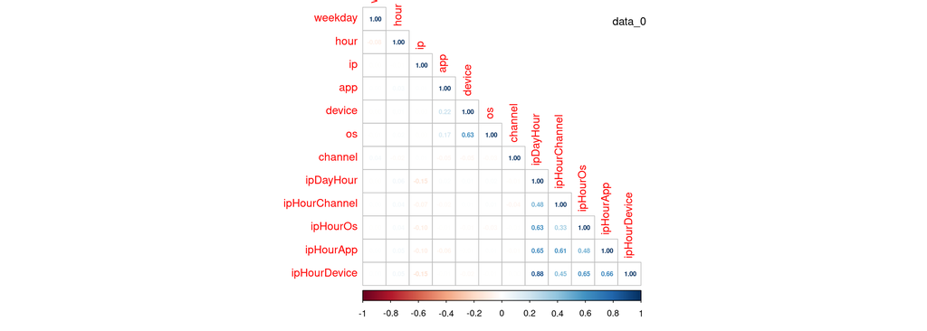

```r
corrplot(cor(data_0, method="pearson"), method = 'number',
         number.cex= 7/ncol(data_0), type="lower")
mtext("data_0", at=12, line=2, cex=1)
```

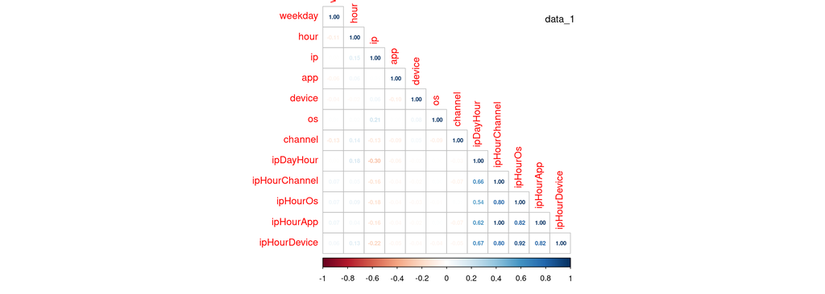

```r
corrplot(cor(data_1, method="pearson"), method = 'number',
         number.cex= 7/ncol(data_1), type="lower")
mtext("data_1", at=12, line=2, cex=1)
```

data_num: only ‘ip’ and ‘app’ are very weakly and positively correlated with the target variable;‘device’ and ‘os’ correlate positively with ‘app’ and with each other.

data_0: particularly, for no-downloads ‘OS’ is high positive correlated with ‘device’, and weakly is ‘app’ with them.

data_1: there are some weakly and very weakly correlations; ‘ip’, ‘app’, and ‘os’ aren’t correlated as ‘data_num’ and ‘data_0’

```r
# End of EAD: removing variables used
rm(df_original, df_IsAttributed0, df_IsAttributed1, df_subsets, df_aux, ip,
   df_IsAttributed0Day, p1_IsA_Day, df_IsAttributed1Day, p2_IsA_Day,
   df_IsAttributed0Hour, p1_IsA_Hour, df_IsAttributed1Hour, p2_IsA_Hour, df, data,
   data_num, data_0, data_1)
```

# 2. Feature Engineering Function

## Data munging

Now that the data is knew let’s automatize its processing and transformations - aux = 0 means for modelling - aux = 1 means for submitting

```r
featureEngineering <- function(data=df[], aux = aux){

  # the same manipulate made in EDA stage
  #data <- data[!duplicated(data), ]
  data$weekday <- as.factor(weekdays(data$click_time))
  data$hour <- as.factor(hour(data$click_time))

  if(aux == 0) {
    #data <- data[!duplicated(data), ]
    data$is_attributed <- as.factor(data$is_attributed)
    data <- data[, c(6,9,10,1,2,3,4,5,7,8)]
    # preparing data for to use in ML algorithms further
    data[,1:9] <- lapply(data[,1:9], as.numeric)
  }
  else if(aux == 1) {
    data <- data[, c(6,8,9,1,2,3,4,5,7)]
    # data[,1:11] <- lapply(data[,1:11], as.numeric)
  }
  #sapply(data_factor, function(x) length(unique(x)))

  # Generating new columns from 'IP' relating it with another columns
  data <- data %>%
    add_count(ip, weekday, hour) %>% rename("ipDayHour"     = n) %>%
    add_count(ip, hour, channel) %>% rename("ipHourChannel" = n) %>%
    add_count(ip, hour, os)      %>% rename("ipHourOs"      = n) %>%
    add_count(ip, hour, app)     %>% rename("ipHourApp"     = n) %>%
    add_count(ip, hour, device)  %>% rename("ipHourDevice"  = n) %>%
    select(-attributed_time, -click_time, -ip)
  # 'IP' can be dynamic or fake, so it was deleted as well
  # 'attributed_time' and 'click_time' were deleted as in EDA stage;

  # preparing data for to use in ML algorithms further
  if(aux == 0) {
    data[,8:12] <- lapply(data[,8:12], as.numeric)
  }
  else if(aux == 1) {
    data[,1:11] <- lapply(data[,1:11], as.numeric)
  }

  #str(data) #glimpse(data)
  return(data)
}
```

# 3. Data Modelling

## Collecting the data

```r
## Setting the working directory
setwd("~/Development/DataScienceAcademy/FCD/BigDataRAzure/ProjetoFinal/TalkingData-AdTracking-Fraud-Detection/Modelling_and_Evaluation")

## Libraries
library(data.table)
library(dplyr)
library(ROSE)
library(caret)
library(ROCR)
library(pROC)
## Loading dataset
df <- fread("../Datasets/train_sample.csv", header=T)
# df <- fread(file.choose(), header=T)
```

## 1st Data Modelling Stage: data munging for data modelling

```r
df <- featureEngineering(df, 0)
```

## 2nd Data Modelling Stage: splitting into train and test datasets

```r
set.seed(123)
rows = sample(1:nrow(df), 0.8*nrow(df))
train = df[rows,]
test = df[-rows,]
```

## 3rd Data Modelling Stage: applying random undersampling to balance the dataset’s class variables:

```r
table(train$is_attributed) # 191*2 = N
```

```
##
##     0     1
## 79809   191
```

```r
under_train <- ovun.sample(is_attributed ~.,
                           data = train,
                           method = "under",
                           N = 382, seed=123)$data  #320 #138104

table(test$is_attributed) #36*2 = N
```

```
##
##     0     1
## 19964    36
```

```r
under_test <- ovun.sample(is_attributed ~.,
                          data = test,
                          method = "under",
                          N = 72, seed=123)$data #134 #134
table(under_train$is_attributed)
```

```
##
##   0   1
## 191 191
```

```r
table(under_test$is_attributed)
```

```
##
##  0  1
## 36 36
```

## 4th Data Modelling Stage: creating the undersampled models

```r
### Model 1: Modelo Naive Bayes
# Creating the Naive Bayes model
set.seed(12345)
model_underNB = train(under_train[,-7], under_train[,7], method='naive_bayes')
# Making predictions on test data:
pred_model_underNB = predict(model_underNB, under_test[,-7])
# creating Confusion Matrix from predictions
confusionMatrix(pred_model_underNB, under_test$is_attributed)
```

```
## Confusion Matrix and Statistics
##
##           Reference
## Prediction  0  1
##          0 29  6
##          1  7 30
##
##                Accuracy : 0.8194
##                  95% CI : (0.7111, 0.9002)
##     No Information Rate : 0.5
##     P-Value [Acc > NIR] : 1.904e-08
##
##                   Kappa : 0.6389
##
##  Mcnemar's Test P-Value : 1
##
##             Sensitivity : 0.8056
##             Specificity : 0.8333
##          Pos Pred Value : 0.8286
##          Neg Pred Value : 0.8108
##              Prevalence : 0.5000
##          Detection Rate : 0.4028
##    Detection Prevalence : 0.4861
##       Balanced Accuracy : 0.8194
##
##        'Positive' Class : 0
##
```

```r
# calculating AUC for this model
underNB_AUC <- auc(roc(as.integer(under_test$is_attributed), as.integer(pred_model_underNB)))
### Model 2: Linear Discriminant Analysis (LDA)
# Creating
set.seed(12345)
model_underLDA = train(under_train[,-7], under_train[,7], method='lda')
# Making predictions
pred_model_underLDA = predict(model_underLDA, under_test[,-7])
# Confusion Matrix
confusionMatrix(pred_model_underLDA, under_test$is_attributed)
```

```
## Confusion Matrix and Statistics
##
##           Reference
## Prediction  0  1
##          0 25 18
##          1 11 18
##
##                Accuracy : 0.5972
##                  95% CI : (0.475, 0.7112)
##     No Information Rate : 0.5
##     P-Value [Acc > NIR] : 0.06246
##
##                   Kappa : 0.1944
##
##  Mcnemar's Test P-Value : 0.26521
##
##             Sensitivity : 0.6944
##             Specificity : 0.5000
##          Pos Pred Value : 0.5814
##          Neg Pred Value : 0.6207
##              Prevalence : 0.5000
##          Detection Rate : 0.3472
##    Detection Prevalence : 0.5972
##       Balanced Accuracy : 0.5972
##
##        'Positive' Class : 0
##
```

```r
# calculating AUC and ROC curve for this model
underLDA_AUC <- auc(roc(as.integer(under_test$is_attributed), as.integer(pred_model_underLDA)))
### Model 3: Decision Tree (rpart)
set.seed(12345)
model_underDT = train(under_train[,-7], under_train[,7], method='rpart')
pred_model_underDT = predict(model_underDT, under_test[,-7])
confusionMatrix(pred_model_underDT, under_test$is_attributed)
```

```
## Confusion Matrix and Statistics
##
##           Reference
## Prediction  0  1
##          0 31  4
##          1  5 32
##
##                Accuracy : 0.875
##                  95% CI : (0.7759, 0.9412)
##     No Information Rate : 0.5
##     P-Value [Acc > NIR] : 2.091e-11
##
##                   Kappa : 0.75
##
##  Mcnemar's Test P-Value : 1
##
##             Sensitivity : 0.8611
##             Specificity : 0.8889
##          Pos Pred Value : 0.8857
##          Neg Pred Value : 0.8649
##              Prevalence : 0.5000
##          Detection Rate : 0.4306
##    Detection Prevalence : 0.4861
##       Balanced Accuracy : 0.8750
##
##        'Positive' Class : 0
##
```

```r
underDT_AUC <- auc(roc(as.integer(under_test$is_attributed), as.integer(pred_model_underDT)))
### Model 4: Random Forest
set.seed(12345)
model_underRF = train(under_train[,-7], under_train[,7], method='rf')
pred_model_underRF = predict(model_underRF, under_test[,-7])
confusionMatrix(pred_model_underRF, under_test$is_attributed)
```

```
## Confusion Matrix and Statistics
##
##           Reference
## Prediction  0  1
##          0 34  4
##          1  2 32
##
##                Accuracy : 0.9167
##                  95% CI : (0.8274, 0.9688)
##     No Information Rate : 0.5
##     P-Value [Acc > NIR] : 3.628e-14
##
##                   Kappa : 0.8333
##
##  Mcnemar's Test P-Value : 0.6831
##
##             Sensitivity : 0.9444
##             Specificity : 0.8889
##          Pos Pred Value : 0.8947
##          Neg Pred Value : 0.9412
##              Prevalence : 0.5000
##          Detection Rate : 0.4722
##    Detection Prevalence : 0.5278
##       Balanced Accuracy : 0.9167
##
##        'Positive' Class : 0
##
```

```r
underRF_AUC <- auc(roc(as.integer(under_test$is_attributed), as.integer(pred_model_underRF)))
# ### Model 5: AdaBoost
# set.seed(12345)
# model_underAda = train(under_train[,-7], under_train[,7], method='adaboost')
# pred_model_underAda = predict(model_underAda, under_test[,-7])
# confusionMatrix(pred_model_underAda, under_test$is_attributed)
# underAda_AUC <- auc(roc(as.integer(under_test$is_attributed), as.integer(pred_model_underAda)))
#
# ### Model 6: Support Vector Machines
# set.seed(12345)
# model_underAda = train(under_train[,-7], under_train[,7], method='svmLinear')
# pred_model_underSVM = predict(model_underSVM, under_test[,-7])
# confusionMatrix(pred_model_underSVM, under_test$is_attributed)
# underSVM_AUC <- auc(roc(as.integer(under_test$is_attributed), as.integer(pred_model_underSVM)))
#
# ### Model 7: Support Vector Machines
# set.seed(12345)
# model_underGBM = train(under_train[,-7], under_train[,7], method='gbm')
# pred_model_underGBM = predict(model_underGBM, under_test[,-7])
# confusionMatrix(pred_model_underGBM, under_test$is_attributed)
# underGBM_AUC <- auc(roc(as.integer(under_test$is_attributed), as.integer(pred_model_underGBM)))
#
# ### Model 8: Neural Network
# set.seed(12345)
# model_underNN = train(under_train[,-7], under_train[,7], method='nnet')
# pred_model_underNN = predict(model_underNN, under_test[,-7])
# confusionMatrix(pred_model_underNN, under_test$is_attributed)
# underNN_AUC <- auc(roc(as.integer(under_test$is_attributed), as.integer(pred_model_underNN)))
```

### ROC curves and AUC of undersampled models

```r
roc.curve(under_test$is_attributed, pred_model_underNB, plotit = T, col = 1)
```

```
## Area under the curve (AUC): 0.819
```

```r
roc.curve(under_test$is_attributed, pred_model_underLDA, plotit = T, col = 2, add=T)
```

```
## Area under the curve (AUC): 0.597
```

```r
roc.curve(under_test$is_attributed, pred_model_underDT, plotit = T, col = 3, add=T)
```

```
## Area under the curve (AUC): 0.875
```

```r
roc.curve(under_test$is_attributed, pred_model_underRF, plotit = T, col = 4, add=T)
```

```
## Area under the curve (AUC): 0.917
```

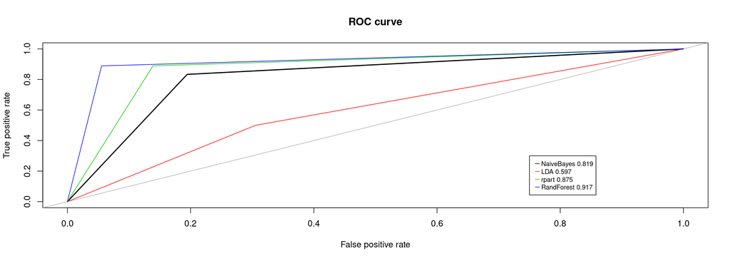

```r
# roc.curve(under_test$is_attributed, pred_model_underAda, plotit = T, col = 5, add=T)
# roc.curve(under_test$is_attributed, pred_model_underSVM, plotit = T, col = 6, add=T)#
# roc.curve(under_test$is_attributed, pred_model_underGBM, plotit = T, col = 7, add=T)#
# roc.curve(under_test$is_attributed, pred_model_underNN, plotit = T, col = 8, add=T)#
legend(y=0.3,x=0.75, bty="o", #"bottomright"
       c(paste("NaiveBayes", round(underNB_AUC, 3)),
         paste("LDA", round(underLDA_AUC, 3)),
         paste("rpart", round(underDT_AUC, 3)),
         paste("RandForest", round(underRF_AUC, 3))
         # paste("AdaBoost", round(underAda_AUC, 3)),
         # paste("SVM", round(underAda_AUC, 3)),
         # paste("GBM", round(underGBM_AUC, 3)),
         # paste("NN", round(underGBM_AUC, 3))
       ),
      col=1:4, lty=1:1, lwd=1, seg.len=0.7, cex=0.75,
       x.intersp=0.3, xjust=0)
```

```r
## creating a AUC values vector for each undersampled model
under_aucModels <- c(
  underNB_AUC  = underNB_AUC,
  underLDA_AUC = underLDA_AUC,
  underDT_AUC  = underDT_AUC,
  underRF_AUC  = underRF_AUC
  # underAda_AUC = underAda_AUC,
  # underSVM_AUC = underSVM_AUC,
  # underGBM_AUC = underGBM_AUC,
  # underNN_AUC  = underNN_AUC
)
### best undersampled model
head(sort(under_aucModels, decreasing = T), 1)
```

```
## underRF_AUC
##   0.9166667
```

```r
# the best is randomForest
```

## 5th Data Modelling Stage: applying random oversampling to balance the dataset’s class variables:

```r
table(train$is_attributed) # 79809*2 = N
```

```
##
##     0     1
## 79809   191
```

```r
over_train <- ovun.sample(is_attributed ~.,
                          data = train,
                          method = "over",
                          N = 159618, seed = 123)$data  #320 #138104

table(test$is_attributed) #19964*2 = N
```

```
##
##     0     1
## 19964    36
```

```r
over_test <- ovun.sample(is_attributed ~.,
                         data = test,
                         method = "over",
                         N = 39926, seed = 123)$data #134 #134

table(over_train$is_attributed)
```

```
##
##     0     1
## 79809 79809
```

```r
table(over_test$is_attributed)
```

```
##
##     0     1
## 19964 19962
```

## 6th Data Modelling Stage: creating the oversampled models

```r
### Model 1: Modelo Naive Bayes
set.seed(12345)
model_overNB = train(over_train[,-7], over_train[,7], method='naive_bayes')
pred_model_overNB = predict(model_overNB, over_test[,-7])
confusionMatrix(pred_model_overNB, over_test$is_attributed)
```

```
## Confusion Matrix and Statistics
##
##           Reference
## Prediction     0     1
##          0 16225  3842
##          1  3739 16120
##
##                Accuracy : 0.8101
##                  95% CI : (0.8062, 0.814)
##     No Information Rate : 0.5
##     P-Value [Acc > NIR] : <2e-16
##
##                   Kappa : 0.6202
##
##  Mcnemar's Test P-Value : 0.2414
##
##             Sensitivity : 0.8127
##             Specificity : 0.8075
##          Pos Pred Value : 0.8085
##          Neg Pred Value : 0.8117
##              Prevalence : 0.5000
##          Detection Rate : 0.4064
##    Detection Prevalence : 0.5026
##       Balanced Accuracy : 0.8101
##
##        'Positive' Class : 0
##
```

```r
overNB_AUC <- auc(roc(as.integer(over_test$is_attributed), as.integer(pred_model_overNB)))
### Model 2: Linear Discriminant Analysis (LDA)
set.seed(12345)
model_overLDA = train(over_train[,-7], over_train[,7], method='lda')
pred_model_overLDA = predict(model_overLDA, over_train[,-7])
confusionMatrix(pred_model_overLDA, over_train$is_attributed)
```

```
## Confusion Matrix and Statistics
##
##           Reference
## Prediction     0     1
##          0 59744 22917
##          1 20065 56892
##
##                Accuracy : 0.7307
##                  95% CI : (0.7285, 0.7329)
##     No Information Rate : 0.5
##     P-Value [Acc > NIR] : < 2.2e-16
##
##                   Kappa : 0.4614
##
##  Mcnemar's Test P-Value : < 2.2e-16
##
##             Sensitivity : 0.7486
##             Specificity : 0.7129
##          Pos Pred Value : 0.7228
##          Neg Pred Value : 0.7393
##              Prevalence : 0.5000
##          Detection Rate : 0.3743
##    Detection Prevalence : 0.5179
##       Balanced Accuracy : 0.7307
##
##        'Positive' Class : 0
##
```

```r
overLDA_AUC <- auc(roc(as.integer(over_train$is_attributed), as.integer(pred_model_overLDA)))
### Model 3: Decision Tree (rpart)
set.seed(12345)
model_overDT = train(over_train[,-7], over_train[,7], method='rpart')
pred_model_overDT = predict(model_overDT, over_test[,-7])
confusionMatrix(pred_model_overDT, over_test$is_attributed)
```

```
## Confusion Matrix and Statistics
##
##           Reference
## Prediction     0     1
##          0 17412  2172
##          1  2552 17790
##
##                Accuracy : 0.8817
##                  95% CI : (0.8785, 0.8848)
##     No Information Rate : 0.5
##     P-Value [Acc > NIR] : < 2.2e-16
##
##                   Kappa : 0.7634
##
##  Mcnemar's Test P-Value : 3.503e-08
##
##             Sensitivity : 0.8722
##             Specificity : 0.8912
##          Pos Pred Value : 0.8891
##          Neg Pred Value : 0.8745
##              Prevalence : 0.5000
##          Detection Rate : 0.4361
##    Detection Prevalence : 0.4905
##       Balanced Accuracy : 0.8817
##
##        'Positive' Class : 0
##
```

```r
overDT_AUC <- auc(roc(as.integer(over_test$is_attributed), as.integer(pred_model_overDT)))
# ### Model 4: Random Forest
# set.seed(12345)
# model_overRF = train(over_train[,-7], over_train[,7], method='rf')
# pred_model_overRF <- predict(model_overRF, over_test)
# confusionMatrix(pred_model_overRF,
#                 over_test$is_attributed,
#                 positive='1')
# overRF_AUC <- auc(roc(as.integer(over_test$is_attributed), as.integer(pred_model_overRF)))

# ### Model 5: AdaBoost (the longest)
# set.seed(12345)
# model_overAda = train(over_train[,-7], over_train[,7], method='adaboost', nIter=1)
# ?adaboost
# pred_model_overAda = predict(model_overAda, over_test[,-7])
# confusionMatrix(pred_model_overAda, over_test$is_attributed)
# overAda_AUC <- auc(roc(as.integer(over_test$is_attributed), as.integer(pred_model_overAda)))
#
# ### Model 6: Support Vector Machines
# library(e1071)
# set.seed(12345)
# model_overSVM = svm(is_attributed ~ .,
#                     data = over_train,
#                     type = 'C-classification',
#                     kernel = 'linear')
# pred_model_overSVM = predict(model_overSVM, over_test[,-7])
# confusionMatrix(pred_model_overSVM, over_test$is_attributed)
# overSVM_AUC <- auc(roc(as.integer(over_test$is_attributed), as.integer(pred_model_overSVM)))
#
# ### Model 7: GBM
# set.seed(12345)
# model_overGBM = train(over_train[,-7], over_train[,7], method='gbm', n.trees=3)
#
# pred_model_overGBM = predict(model_overGBM, over_test[,-7])
# confusionMatrix(pred_model_overGBM, over_test$is_attributed)
# overGBM_AUC <- auc(roc(as.integer(over_test$is_attributed), as.integer(pred_model_overGBM)))
#
# # ### Model 8: Neural Network
# set.seed(12345)
# model_overNN = train(over_train[,-7], over_train[,7], method='nnet', nIter=2)
# pred_model_overNN = predict(model_overNN, over_test[,-7])
# confusionMatrix(pred_model_overNN, over_test$is_attributed)
# overNN_AUC <- auc(roc(as.integer(over_test$is_attributed), as.integer(pred_model_overNN)))
```

### ROC curves and AUC of oversampled models

```r
roc.curve(over_test$is_attributed, pred_model_overNB, plotit = T, col = 1)
```

```
## Area under the curve (AUC): 0.810
```

```r
roc.curve(over_train$is_attributed, pred_model_overLDA, plotit = T, col = 2, add=T)
```

```
## Area under the curve (AUC): 0.731
```

```r
roc.curve(over_test$is_attributed, pred_model_overDT, plotit = T, col = 3, add=T)
```

```
## Area under the curve (AUC): 0.882
```

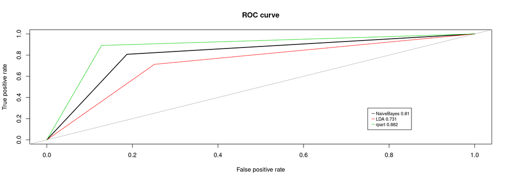

```r
#roc.curve(over_test$is_attributed, pred_model_overRF, plotit = T, col = 4, add=T)
# roc.curve(over_test$is_attributed, pred_model_overAda, plotit = T, col = 5, add=T)
# roc.curve(over_test$is_attributed, pred_model_overSVM, plotit = T, col = 6, add=T)
# roc.curve(over_test$is_attributed, pred_model_overGBM, plotit = T, col = 7, add=T)
# roc.curve(over_test$is_attributed, pred_model_overNN, plotit = T, col = 8, add=T)
legend(y=0.3,x=0.75, bty="o", #"bottomright"
       c(paste("NaiveBayes", round(overNB_AUC, 3)),
         paste("LDA", round(overLDA_AUC, 3)),
         paste("rpart", round(overDT_AUC, 3))
         #paste("RandForest", round(overRF_AUC, 3))
         # paste("AdaBoost", round(overAda_AUC, 3)),
         # paste("SVM", round(overSVM_AUC, 3)),
         # paste("GBM", round(overGBM_AUC, 3)),
         # paste("NN", round(overNN_AUC, 3))
       ),
       col=1:3, lty=1:1, lwd=1, seg.len=0.7, cex=0.75,
       x.intersp=0.3, xjust=0)
```

```r
# creating a AUC values vector for each oversampled model
over_aucModels <- c(
  overNB_AUC  = overNB_AUC,
  overLDA_AUC = overLDA_AUC,
  overDT_AUC  = overDT_AUC
  #overRF_AUC  = overRF_AUC
  # overAda_AUC = overAda_AUC,
  # overSVM_AUC = overSVM_AUC,
  # overGBM_AUC = overGBM_AUC
  # overNN_AUC = overNN_AUC
)
# best oversampled model
head(sort(over_aucModels, decreasing = T), 1)
```

```
## overDT_AUC
##  0.8816816
```

```r
# So, the best of all models is really the undersampled randomForest
```

## 7th Data Modelling Stage: optimizing the best model -> Undersampled Random Forest

```r
set.seed(12345)
model_underRFop = train(under_train[,-7], under_train[,7],
                      method='rf',
                      metric="Accuracy",
                      ntree = 100,
                      nodesize = 10)
pred_model_underRFop = predict(model_underRFop, under_test[,-7])
confusionMatrix(pred_model_underRFop, under_test$is_attributed)
```

```
## Confusion Matrix and Statistics
##
##           Reference
## Prediction  0  1
##          0 34  3
##          1  2 33
##
##                Accuracy : 0.9306
##                  95% CI : (0.8453, 0.9771)
##     No Information Rate : 0.5
##     P-Value [Acc > NIR] : 3.194e-15
##
##                   Kappa : 0.8611
##
##  Mcnemar's Test P-Value : 1
##
##             Sensitivity : 0.9444
##             Specificity : 0.9167
##          Pos Pred Value : 0.9189
##          Neg Pred Value : 0.9429
##              Prevalence : 0.5000
##          Detection Rate : 0.4722
##    Detection Prevalence : 0.5139
##       Balanced Accuracy : 0.9306
##
##        'Positive' Class : 0
##
```

```r
underRF_AUCop <- auc(roc(as.integer(under_test$is_attributed), as.integer(pred_model_underRFop)))
```

```r
# the model was improved
roc.curve(under_test$is_attributed, pred_model_underRF, plotit = T, col = 1)
```

```
## Area under the curve (AUC): 0.917
```

```r
roc.curve(under_test$is_attributed, pred_model_underRFop, plotit = T, col = 2, add=T)
```

```
## Area under the curve (AUC): 0.931
```

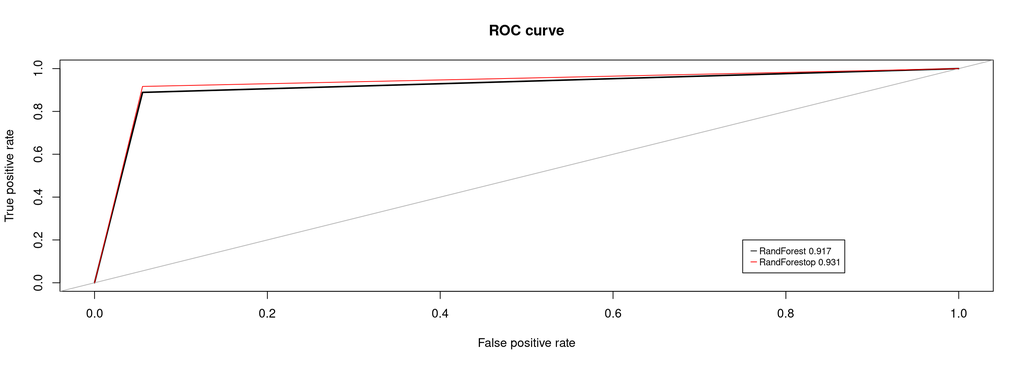

```r
legend(y=0.2,x=0.75, bty="o", #"bottomright"
       c(paste("RandForest", round(underRF_AUC, 3)),
         paste("RandForestop", round(underRF_AUCop, 3))
       ),
       col=1:2, lty=1:1, lwd=1, seg.len=0.7, cex=0.75,
       x.intersp=0.3, xjust=0)
```

```r
chosenModel <- model_underRFop
```

So, the best model really is the “improved undersampled random forest”

# 4.File Submission on Kaggle

```r
## loading "test" kaggle dataset
#submit <- fread(file.choose(), header=T)
submit <- fread("../Datasets/test.csv", header=T)

# to keep in safe 'click_id' column
submit1 <- submit[,-1]
submit1$attributed_time <- 0

## preparing data for modelling
submit1 <- featureEngineering(submit1, 1)
#gc() # to free memory

## predicting the test
p <- predict(chosenModel, submit1)

## generating the dataframe that will be submited
d <- data.frame(click_id = submit$click_id, is_attributed = p)
fwrite(d, "submit_op_under_rf.csv")
```

Finally, the scores AUC metric in Kaggle by this model was: - Private Score: 0.87182~0.87193 - Public Score: 0.87675~0.87668

# Get in touch with me

## If you have any questions, suggestions or just want to exchange an idea about this project, don’t hesitate to get in touch with me!